# 課題14 解答：state dependenceの識別と買いだめの反実仮想

計量経済学II

作者

Kei Ikegami

**重要この解答の使い方**

各問について、完全な実行可能コード・「なぜこう書くか」の解説・部分点基準を示す。まず自分の解答と突き合わせ、次に解説を読んで、なぜその実装が正しいのかを理解してほしい。数値は乱数シードに依存してわずかに変動するが、**大きさのオーダー**（何倍過大評価するか、など）は安定している。

# Part 1：ブランド選択パネルのDGPを自作する（30点）

## 問1（20点）：DGP関数を完成させる

```r
softmax_probs <- function(V) {
  V_full <- cbind(0, V)
  V_full <- V_full - apply(V_full, 1, max)
  eV <- exp(V_full)
  eV / rowSums(eV)
}

simulate_panel_mnl <- function(N, Tn, burn, lambda, sigma_mu,
                                price_sd = 0.3, beta_price = -1.0,
                                const = c(-0.3, -0.4), seed = 1) {
  set.seed(seed)
  mu_i <- matrix(rnorm(N * 2, 0, sigma_mu), N, 2)
  y_prev <- rep(0L, N)
  total_T <- burn + Tn
  y_mat <- matrix(0L, N, Tn)
  price_mat <- array(0, dim = c(N, Tn, 2))

  for (t in 1:total_T) {
    price_t <- matrix(rnorm(N * 2, 0, price_sd), N, 2)
    lag1 <- as.numeric(y_prev == 1L)
    lag2 <- as.numeric(y_prev == 2L)
    V1 <- const[1] + beta_price * price_t[, 1] + lambda * lag1 + mu_i[, 1]
    V2 <- const[2] + beta_price * price_t[, 2] + lambda * lag2 + mu_i[, 2]
    probs <- softmax_probs(cbind(V1, V2))
    u <- runif(N)
    cum_probs <- t(apply(probs, 1, cumsum))
    y_t <- rowSums(u > cum_probs)

    if (t > burn) {
      y_mat[, t - burn] <- y_t
      price_mat[, t - burn, ] <- price_t
    }
    y_prev <- y_t
  }
  list(y = y_mat, price = price_mat, mu = mu_i)
}

N <- 1000; Tn <- 20; BURN <- 30
lambda_true <- 1.0
sigma_mu_true <- 1.2

dgp <- simulate_panel_mnl(N, Tn, BURN, lambda = lambda_true, sigma_mu = sigma_mu_true, seed = 141)
cat("dim(y):", dim(dgp$y), "\n")
```

```
dim(y): 1000 20
```

```r
cat("dim(price):", dim(dgp$price), "\n")
```

```
dim(price): 1000 20 2
```

**解説**：`lag1 <- as.numeric(y_prev == 1L)`が核心だ。`y_prev`は前期の選択（0/1/2の整数）を保持しており、「前期にbrand1を買ったか」は論理演算`y_prev == 1L`で判定し、`as.numeric()`で0/1の数値に変換する。`cum_probs <- t(apply(probs, 1, cumsum))`は各行（個人）ごとに累積確率を作り、`rowSums(u > cum_probs)`で逆関数法による選択を実現する。`u`が小さいほど、より小さいインデックスの選択肢（outside寄り）が選ばれる仕組みだ。

**部分点基準**：`lag1`・`lag2`の穴埋めが正しい（10点）。関数全体が正しく走り、`y`が0/1/2のみを含む(N x Tn)行列になっている（10点）。

## 問2（10点）：記述統計

```r
# (a) 全体シェア
cat("choice shares:\n")
```

```
choice shares:
```

```r
print(table(dgp$y) / length(dgp$y))
```

```
      0       1       2
0.27855 0.36575 0.35570
```

```r
# (b) ブランド1のリピート率
y_lag <- dgp$y[, -Tn]
y_now <- dgp$y[, -1]
p_repeat <- mean(y_now[y_lag == 1] == 1)
p_switch <- mean(y_now[y_lag != 1] == 1)
cat("P(brand1 | 前回brand1):", round(p_repeat, 4), "\n")
```

```
P(brand1 | 前回brand1): 0.679
```

```r
cat("P(brand1 | 前回brand1以外):", round(p_switch, 4), "\n")
```

```
P(brand1 | 前回brand1以外): 0.1862
```

```r
cat("リピート率ギャップ:", round(p_repeat - p_switch, 4), "\n")
```

```
リピート率ギャップ: 0.4927
```

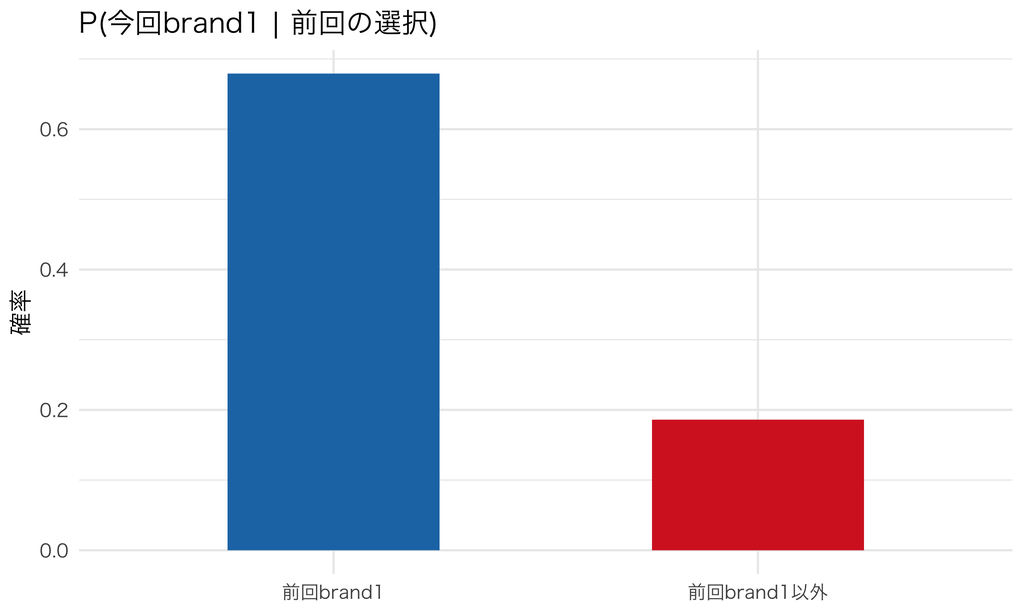

ブランド1のリピート率ギャップ

```r
# wide形式（前回brand1/前回brand1以外を列に持つ）で作ってからpivot_longerでlong化する
df_repeat_wide <- data.frame(prev_brand1 = p_repeat, prev_other = p_switch)
df_repeat_long <- df_repeat_wide %>%
  pivot_longer(cols = everything(), names_to = "condition", values_to = "prob") %>%
  mutate(condition = recode(condition, prev_brand1 = "前回brand1", prev_other = "前回brand1以外"))

ggplot(df_repeat_long, aes(condition, prob, fill = condition)) +
  geom_col(width = 0.5, show.legend = FALSE) +
  scale_fill_manual(values = c("前回brand1" = "#1f77b4", "前回brand1以外" = "#d62728")) +
  labs(title = "P(今回brand1 | 前回の選択)", x = NULL, y = "確率")
```

**警告典型的なバグ：確率が1を超える**

`mean(y_now[y_lag == 1])`（`== 1`を付け忘れる）と書くと、「brand1を選んだ確率」ではなく「y_now（0,1,2の値そのもの）の平均」を計算してしまい、1を超える意味のない数字が出る。これは執筆者自身がプロトタイプ検証で実際に踏んだバグである。`y_now[y_lag == 1] == 1`のように、まず条件で絞り込み、そのうえで`== 1`により「今回の選択がbrand1か」を判定する、**2段階の条件抽出**を徹底すること。

**部分点基準**：シェアの計算が正しい（3点）。`p_repeat`・`p_switch`の計算が正しい（`== 1`の2段階抽出ができている）（5点）。可視化ができている（2点）。

# Part 2：推定・placebo・買いだめ（70点）

## 問3（15点）：naiveなpooled multinomial logitでlambda_hatの過大評価を確認する

```r
mnl_loglik <- function(theta, y, p1, p2, lag1, lag2) {
  c1 <- theta[1]; c2 <- theta[2]; bp <- theta[3]; lam <- theta[4]
  V1 <- c1 + bp * p1 + lam * lag1
  V2 <- c2 + bp * p2 + lam * lag2
  V_full <- cbind(0, V1, V2)
  V_full <- V_full - apply(V_full, 1, max)
  eV <- exp(V_full)
  probs <- eV / rowSums(eV)
  n <- length(y)
  chosen_probs <- probs[cbind(1:n, y + 1)]
  sum(log(pmax(chosen_probs, 1e-300)))
}

mnl_mle <- function(y, p1, p2, lag1, lag2) {
  neg_ll <- function(theta) -mnl_loglik(theta, y, p1, p2, lag1, lag2)
  opt <- optim(par = c(0, 0, 0, 0), fn = neg_ll, method = "BFGS")
  opt$par
}

build_pooled_mnl_df <- function(sim) {
  Nn <- dim(sim$y)[1]; Tn <- dim(sim$y)[2]
  y_lag <- sim$y[, -Tn]; y_now <- sim$y[, -1]
  price_now <- sim$price[, -1, ]
  list(
    y    = as.vector(y_now),
    p1   = as.vector(price_now[, , 1]),
    p2   = as.vector(price_now[, , 2]),
    lag1 = as.numeric(as.vector(y_lag == 1)),
    lag2 = as.numeric(as.vector(y_lag == 2))
  )
}

df_naive <- build_pooled_mnl_df(dgp)
theta_naive <- mnl_mle(df_naive$y, df_naive$p1, df_naive$p2, df_naive$lag1, df_naive$lag2)
cat("estimated (c1, c2, beta_p, lambda):\n")
```

```
estimated (c1, c2, beta_p, lambda):
```

```r
print(round(theta_naive, 3))
```

```
[1] -0.558 -0.580 -0.835  1.750
```

```r
cat("true lambda =", lambda_true, "\n")
```

```
true lambda = 1
```

**解説**：`mnl_loglik`は3択softmaxの対数尤度そのものだ。`probs[cbind(1:n, y+1)]`という書き方が肝で、各観測$i$について「実際に選んだ選択肢（列番号は`y[i]+1`、outside=0なら列1、brand1=1なら列2、brand2=2なら列3）」の確率だけを取り出す、Rの行列添字を使ったベクトル化トリックである。`optim(method="BFGS")`で数値的に対数尤度を最大化する。

**ノートなぜnaiveのバイアスがここまで大きいのか**

講義ノートのDGP(b)（$\lambda=0$、異質性のみ）では、naiveな$\hat\lambda$は真値0に対して約1.0前後の過大評価だった。本課題のメインDGPは真の$\lambda=1.0$に対して、さらに異質性由来の過大評価が「上乗せ」されるので、$\hat\lambda\approx 1.7$〜$1.8$という、真値の1.7〜1.8倍という大きな数字になる。これは「naiveな推定でstate dependenceの大きさを語ることがいかに危険か」を、より劇的な形で示す結果だと理解してほしい。

**部分点基準**：`mnl_loglik`の実装が正しい（softmaxの計算、選んだ確率の取り出し）（8点）。`build_pooled_mnl_df`の`lag1`・`lag2`が正しい（4点）。`optim`が収束し、$\hat\lambda$が真値を大きく上回ることを確認・言及している（3点）。

## 問4（15点）：Wooldridge deviceでの改善を確認する

```r
build_wooldridge_mnl_df <- function(sim) {
  Nn <- dim(sim$y)[1]; Tn <- dim(sim$y)[2]
  y0 <- sim$y[, 1]
  y0_is1 <- as.numeric(y0 == 1)
  y0_is2 <- as.numeric(y0 == 2)
  price_bar1 <- rowMeans(sim$price[, -1, 1])
  price_bar2 <- rowMeans(sim$price[, -1, 2])

  y_lag <- sim$y[, -Tn]; y_now <- sim$y[, -1]
  price_now <- sim$price[, -1, ]
  Tm1 <- Tn - 1
  list(
    y    = as.vector(y_now),
    p1   = as.vector(price_now[, , 1]),
    p2   = as.vector(price_now[, , 2]),
    lag1 = as.numeric(as.vector(y_lag == 1)),
    lag2 = as.numeric(as.vector(y_lag == 2)),
    y0_1 = rep(y0_is1, times = Tm1),
    y0_2 = rep(y0_is2, times = Tm1),
    pbar1 = rep(price_bar1, times = Tm1),
    pbar2 = rep(price_bar2, times = Tm1)
  )
}

mnl_loglik_wool <- function(theta, d) {
  c1 <- theta[1]; c2 <- theta[2]; bp <- theta[3]; lam <- theta[4]
  r01 <- theta[5]; r02 <- theta[6]; rp1 <- theta[7]; rp2 <- theta[8]
  V1 <- c1 + bp * d$p1 + lam * d$lag1 + r01 * d$y0_1 + rp1 * d$pbar1
  V2 <- c2 + bp * d$p2 + lam * d$lag2 + r02 * d$y0_2 + rp2 * d$pbar2
  V_full <- cbind(0, V1, V2)
  V_full <- V_full - apply(V_full, 1, max)
  eV <- exp(V_full)
  probs <- eV / rowSums(eV)
  n <- length(d$y)
  chosen_probs <- probs[cbind(1:n, d$y + 1)]
  sum(log(pmax(chosen_probs, 1e-300)))
}

mnl_mle_wool <- function(d) {
  neg_ll <- function(theta) -mnl_loglik_wool(theta, d)
  opt <- optim(par = rep(0, 8), fn = neg_ll, method = "BFGS")
  opt$par
}

df_wool <- build_wooldridge_mnl_df(dgp)
theta_wool <- mnl_mle_wool(df_wool)
cat("naive lambda_hat:     ", round(theta_naive[4], 3), "\n")
```

```
naive lambda_hat:      1.75
```

```r
cat("wooldridge lambda_hat:", round(theta_wool[4], 3), "\n")
```

```
wooldridge lambda_hat: 1.559
```

```r
cat("true lambda:          ", lambda_true, "\n")
```

```
true lambda:           1
```

**解説**：`V2 <- c2 + bp * d$p2 + lam * d$lag2 + r02 * d$y0_2 + rp2 * d$pbar2`が問4の唯一の穴埋めだ。V1の式と完全に対称的に、brand2用の変数（`d$lag2`, `d$y0_2`, `d$pbar2`）と、brand2固有の係数（`c2`, `r02`, `rp2`）を組み合わせる。共通の係数は`bp`（価格）と`lam`（状態依存、両ブランドで共通と仮定している点に注意）だけだ。

Pythonでの検証では、$\hat\lambda_{\text{naive}}\approx 1.83$に対し、Wooldridge deviceを使うと$\hat\lambda_{\text{wool}}\approx 1.6$程度までしか下がらなかった。改善はわずかである。

**重要ここでも「効くが完治しない」**

このメインDGPは真の$\lambda=1.0$を含むため、単純な「バイアスが何%縮小したか」という計算は問5のplacebo実験（真の$\lambda=0$）の方が解釈しやすい。ここで確認してほしいのは、**Wooldridge deviceを使っても$\hat\lambda$が真値1.0にきれいには戻らない**という事実そのものだ。$y_{i0}$と$\overline{\text{price}}_i$は$\mu_i$の不完全な代理変数にすぎず、講義ノートで学んだ「効くが完治しない」教訓がここでも成り立つ。

**部分点基準**：`V2`の穴埋めが正しい（V1と対称的な形になっている）（8点）。8パラメータのMLEが収束し、$\hat\lambda_{\text{naive}}$との比較ができている（7点）。

## 問5（20点）：placebo実験——見せかけの状態依存を自分で作る

```r
# (i) placebo DGP: lambda=0, 異質性のみ（sigma_muを大きめに設定）
dgp_placebo <- simulate_panel_mnl(N, Tn, BURN, lambda = 0, sigma_mu = 1.5, seed = 142)

# (ii) naive推定
df_placebo <- build_pooled_mnl_df(dgp_placebo)
theta_placebo_naive <- mnl_mle(df_placebo$y, df_placebo$p1, df_placebo$p2,
                                df_placebo$lag1, df_placebo$lag2)
cat("placebo DGP (true lambda=0) でのnaive lambda_hat:", round(theta_placebo_naive[4], 3), "\n")
```

```
placebo DGP (true lambda=0) でのnaive lambda_hat: 1.093
```

```r
# (iii) Wooldridge deviceでの改善も確認
df_placebo_wool <- build_wooldridge_mnl_df(dgp_placebo)
theta_placebo_wool <- mnl_mle_wool(df_placebo_wool)
cat("placebo DGP でのWooldridge lambda_hat:", round(theta_placebo_wool[4], 3), "\n")
```

```
placebo DGP でのWooldridge lambda_hat: 0.847
```

```r
pct_reduction <- (1 - theta_placebo_wool[4] / theta_placebo_naive[4]) * 100
cat("Wooldridgeによる偽lambdaの縮小率:", round(pct_reduction, 1), "%\n")
```

```
Wooldridgeによる偽lambdaの縮小率: 22.5 %
```

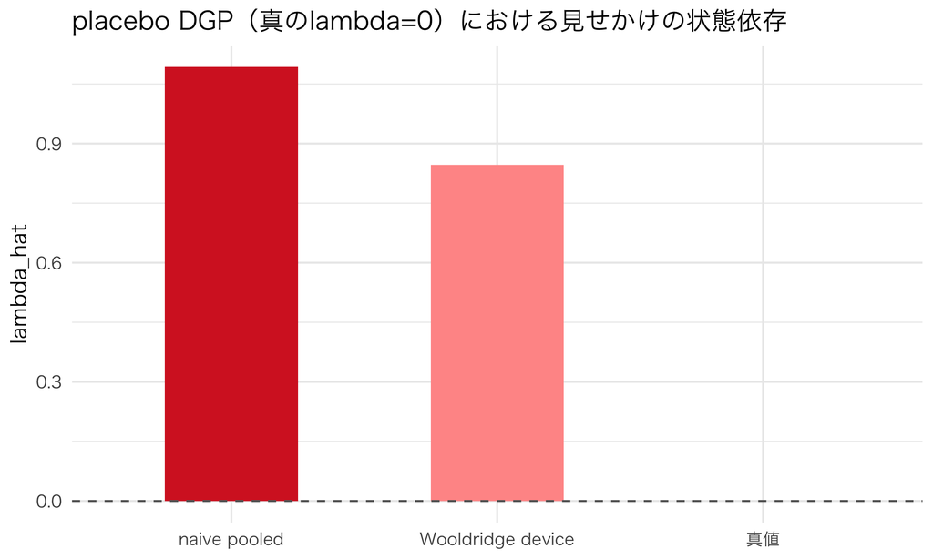

placebo DGP（真のlambda=0）：naive vs Wooldridge

```r
df_placebo_plot <- data.frame(
  method = factor(c("naive pooled", "Wooldridge device", "真値"),
                   levels = c("naive pooled", "Wooldridge device", "真値")),
  lambda_hat = c(theta_placebo_naive[4], theta_placebo_wool[4], 0)
)
ggplot(df_placebo_plot, aes(method, lambda_hat, fill = method)) +
  geom_col(width = 0.5, show.legend = FALSE) +
  geom_hline(yintercept = 0, linetype = "dashed", color = "grey40") +
  scale_fill_manual(values = c("#d62728", "#ff9896", "#2ca02c")) +
  labs(title = "placebo DGP（真のlambda=0）における見せかけの状態依存",
       x = NULL, y = "lambda_hat")
```

**解釈（2〜3文の例）**：「真のstate dependenceが存在しない（$\lambda=0$）にもかかわらず、naiveなpooled multinomial logitは$\hat\lambda\approx 1.1$という大きな偽の効果を検出した。これは個人異質性がラグ選択変数を通じて$\lambda$に取り込まれてしまうためであり、実務でラグ付き変数の係数だけを見て『ロイヤルティがある』と判断することの危険性を裏付けている。Wooldridge deviceはこのバイアスを2割程度縮小するが、大部分（約8割）は残ったままであり、過信は禁物である。」

**ノートsigma_muを小さくすると何が起きるか**

`sigma_mu`を0.5程度まで下げて再実行すると、naiveの$\hat\lambda$も小さくなるはずだ（異質性が弱ければ、見せかけの状態依存も弱くなる）。逆に`sigma_mu`を2.0以上にすると、$\hat\lambda$はさらに大きくなる。この感度こそが「異質性の大きさが、見せかけのstate dependenceの大きさを決める」という講義ノートの主張の直接的な確認になる。

**部分点基準**：placebo DGPを正しく生成している（$\lambda=0$、$\sigma_\mu$を大きめに設定）（5点）。naive推定で真値0から大きく外れた$\hat\lambda$を検出している（5点）。Wooldridge deviceでの改善率を正しく計算している（5点）。2〜3文の解釈が「異質性が状態依存に取り込まれる」というメカニズムに正しく言及している（5点）。

### 問3〜5の結果を1つの表にまとめる

メインDGP（真の$\lambda=1.0$）とplacebo DGP（真の$\lambda=0$）、それぞれのnaive・Wooldridge推定を、wide形式でまとめてから`pivot_longer`でグラフ用のlong形式に変換する。

```r
result_wide <- data.frame(
  dgp = c("メインDGP\n(true lambda=1.0)", "placebo DGP\n(true lambda=0)"),
  true_lambda = c(lambda_true, 0),
  naive = c(theta_naive[4], theta_placebo_naive[4]),
  wooldridge = c(theta_wool[4], theta_placebo_wool[4])
)

result_long <- result_wide %>%
  pivot_longer(cols = c(naive, wooldridge), names_to = "method", values_to = "lambda_hat") %>%
  mutate(method = recode(method, naive = "naiveなpooled logit", wooldridge = "Wooldridge device"),
         gap_from_true = lambda_hat - true_lambda)

result_long %>%
  select(dgp, method, true_lambda, lambda_hat, gap_from_true) %>%
  kable(digits = 3, caption = "メインDGP・placebo DGPを通じたlambda_hatの一覧（正の値ほど過大評価）")
```

メインDGP・placebo DGPを通じたlambda_hatの一覧（正の値ほど過大評価）

[output not shown]

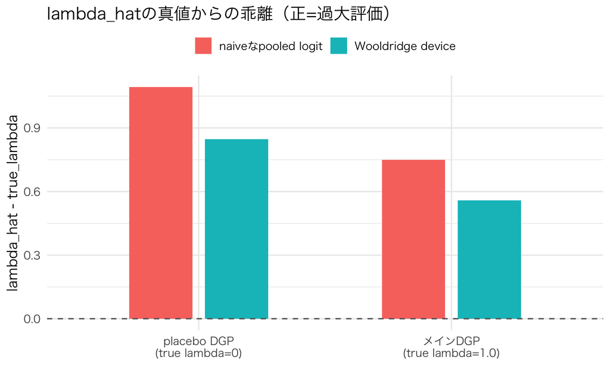

メインDGP・placebo DGPそれぞれで、naiveとWooldridgeがlambda_trueをどれだけ超過するか

```r
ggplot(result_long, aes(dgp, gap_from_true, fill = method)) +
  geom_col(position = position_dodge(width = 0.6), width = 0.5) +
  geom_hline(yintercept = 0, linetype = "dashed", color = "grey40") +
  labs(title = "lambda_hatの真値からの乖離（正=過大評価）",
       x = NULL, y = "lambda_hat - true_lambda", fill = NULL) +
  theme(legend.position = "top")
```

どちらのDGPでも、naiveの方がWooldridgeより真値からの乖離が大きく、Wooldridgeは改善するが乖離がゼロにはならない、という同じパターンが繰り返されていることが一目でわかる。

## 問6（15点）：買いだめDPと反実仮想

```r
Xmax <- 6; Amax <- 4
beta_dp <- 0.95
u_consume <- 2.5
c_hold <- 0.10
stockout_cost <- 1.8
p_regular <- 1.00
p_sale <- 0.70
sale_prob <- 1/10
q_base <- 0.55; q_slope <- 0.025

q_of_x <- function(x) pmin(q_base + q_slope * x, 0.95)
states <- 0:Xmax
actions <- 0:Amax

expected_flow_continuation <- function(x, a, p, V) {
  post <- x + a
  q <- q_of_x(post)
  val_consume <- {
    consumption <- as.numeric(post >= 1)
    end_inv <- post - consumption
    cost <- p * a + c_hold * end_inv
    benefit <- u_consume * consumption
    benefit - cost + beta_dp * V[end_inv + 1]
  }
  val_noconsume <- {
    end_inv <- post
    cost <- p * a + c_hold * end_inv
    benefit <- -(if (post == 0) stockout_cost else 0)
    benefit - cost + beta_dp * V[end_inv + 1]
  }
  q * val_consume + (1 - q) * val_noconsume
}

solve_inventory_dp_general <- function(sale_prob_arg, tol = 1e-10, maxit = 3000) {
  V <- rep(0, Xmax + 1)
  prices <- c(p_regular, p_sale)
  probs_price <- c(1 - sale_prob_arg, sale_prob_arg)
  policy <- matrix(0L, 2, Xmax + 1)
  for (it in 1:maxit) {
    pol_new <- matrix(0L, 2, Xmax + 1)
    for (pi_idx in 1:2) {
      p <- prices[pi_idx]
      for (xi in seq_along(states)) {
        x <- states[xi]
        best_val <- -Inf; best_a <- 0
        for (a in actions) {
          if (x + a > Xmax) next
          val <- expected_flow_continuation(x, a, p, V)
          if (val > best_val) { best_val <- val; best_a <- a }
        }
        pol_new[pi_idx, xi] <- best_a
      }
    }
    V_new <- numeric(Xmax + 1)
    for (xi in seq_along(states)) {
      x <- states[xi]
      v_x <- 0
      for (pi_idx in 1:2) {
        a <- pol_new[pi_idx, xi]
        v_x <- v_x + probs_price[pi_idx] * expected_flow_continuation(x, a, prices[pi_idx], V)
      }
      V_new[xi] <- v_x
    }
    err <- max(abs(V_new - V))
    V <- V_new; policy <- pol_new
    if (err < tol) break
  }
  list(V = V, policy = policy, iters = it)
}

dp_base   <- solve_inventory_dp_general(1/10)
dp_double <- solve_inventory_dp_general(1/5)

cat("通常頻度(1/10)での政策関数(通常価格):\n"); print(dp_base$policy[1, ])
```

```
通常頻度(1/10)での政策関数(通常価格):
```

```
[1] 1 0 0 0 0 0 0
```

```r
cat("通常頻度(1/10)での政策関数(セール価格):\n"); print(dp_base$policy[2, ])
```

```
通常頻度(1/10)での政策関数(セール価格):
```

```
[1] 2 1 0 0 0 0 0
```

```r
cat("倍増頻度(1/5)での政策関数(セール価格):\n"); print(dp_double$policy[2, ])
```

```
倍増頻度(1/5)での政策関数(セール価格):
```

```
[1] 2 1 0 0 0 0 0
```

在庫0のとき通常価格では1単位だけ、セール価格では2単位買う政策が出る（講義ノートと定性的に同じ形）。

```r
# (b) セール頻度2倍の反実仮想
simulate_calendar_general <- function(N_hh, Tn, sale_bool, policy, sale_prob_arg, seed = 1, burn_in = 120) {
  set.seed(seed)
  x <- rep(0L, N_hh)
  for (t in 1:burn_in) {
    is_sale <- runif(N_hh) < sale_prob_arg
    a <- ifelse(is_sale, policy[2, x + 1], policy[1, x + 1])
    post <- x + a
    q <- q_of_x(post)
    occ <- runif(N_hh) < q
    consumption <- as.integer(occ & post >= 1)
    x <- post - consumption
  }
  units_sold <- numeric(Tn); revenue <- numeric(Tn)
  for (t in 1:Tn) {
    on_sale <- sale_bool[t]
    p <- if (on_sale) p_sale else p_regular
    a <- if (on_sale) policy[2, x + 1] else policy[1, x + 1]
    units_sold[t] <- sum(a)
    revenue[t] <- sum(a) * p
    post <- x + a
    q <- q_of_x(post)
    occ <- runif(N_hh) < q
    consumption <- as.integer(occ & post >= 1)
    x <- post - consumption
  }
  list(units = units_sold, revenue = revenue)
}

unit_cost <- 0.40
N_hh <- 15000
Tprobe <- 300

set.seed(11)
sale_bool_base   <- runif(Tprobe) < 1/10
set.seed(11)
sale_bool_double <- runif(Tprobe) < 1/5

res_base   <- simulate_calendar_general(N_hh, Tprobe, sale_bool_base,   dp_base$policy,   1/10, seed = 321)
res_double <- simulate_calendar_general(N_hh, Tprobe, sale_bool_double, dp_double$policy, 1/5,  seed = 321)

window <- 20:Tprobe
total_units_base   <- sum(res_base$units[window])
total_units_double <- sum(res_double$units[window])
profit_base   <- sum(res_base$revenue[window])   - total_units_base   * unit_cost
profit_double <- sum(res_double$revenue[window]) - total_units_double * unit_cost

pct_units_change  <- (total_units_double / total_units_base - 1) * 100
pct_profit_change <- (profit_double / profit_base - 1) * 100
cat("総販売数量の変化(%):", round(pct_units_change, 2), "\n")
```

```
総販売数量の変化(%): 0.7
```

```r
cat("利益の変化(%):", round(pct_profit_change, 2), "\n")
```

```
利益の変化(%): -12.11
```

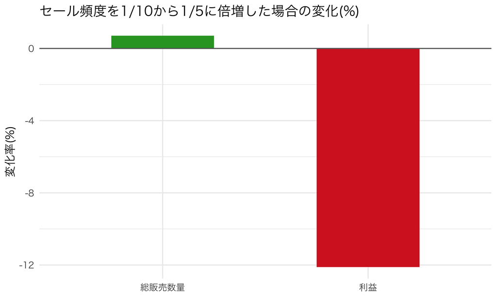

セール頻度2倍の反実仮想（本課題のパラメータ）

```r
df_double <- data.frame(
  metric = factor(c("総販売数量", "利益"), levels = c("総販売数量", "利益")),
  pct_change = c(pct_units_change, pct_profit_change)
)
ggplot(df_double, aes(metric, pct_change, fill = pct_change > 0)) +
  geom_col(width = 0.5, show.legend = FALSE) +
  geom_hline(yintercept = 0, color = "grey40") +
  scale_fill_manual(values = c("TRUE" = "#2ca02c", "FALSE" = "#d62728")) +
  labs(title = "セール頻度を1/10から1/5に倍増した場合の変化(%)", x = NULL, y = "変化率(%)")
```

Pythonでの検証では、総販売数量はほぼ不変（+0.6%程度）、利益は約12%減少した。講義ノートの結果（数量+0.9%、利益-11.8%）と非常に近く、パラメータが変わっても「買いだめが強い財ではセール頻度を上げても総量は増えず、利益率の高い通常価格販売が安値販売に置き換わるだけ」という定性的結論は頑健である。

```r
# (c) 短期・長期弾力性
sale_bool_event <- rep(FALSE, 25); sale_bool_event[10] <- TRUE
units_event <- simulate_calendar_general(N_hh, 25, sale_bool_event, dp_base$policy, 1/10, seed = 42)$units
units_none  <- simulate_calendar_general(N_hh, 25, rep(FALSE, 25),  dp_base$policy, 1/10, seed = 42)$units
pct_cut <- p_sale / p_regular - 1
sr_pct_change <- units_event[10] / units_none[10] - 1
sr_elasticity <- sr_pct_change / pct_cut

stationary_units <- function(always_sale, seed) {
  Tp <- 60
  sale_bool <- rep(always_sale, Tp)
  sp_for_burnin <- if (always_sale) 1 else 0
  u <- simulate_calendar_general(N_hh, Tp, sale_bool, dp_base$policy, sp_for_burnin, seed = seed, burn_in = 150)$units
  mean(tail(u, 15))
}
units_permanent_sale    <- stationary_units(TRUE,  seed = 99)
units_permanent_regular <- stationary_units(FALSE, seed = 100)
lr_pct_change <- units_permanent_sale / units_permanent_regular - 1
lr_elasticity <- lr_pct_change / pct_cut

cat("短期弾力性:", round(sr_elasticity, 3), "\n")
```

```
短期弾力性: -5.845
```

```r
cat("長期弾力性:", round(lr_elasticity, 3), "\n")
```

```
長期弾力性: -0.142
```

```r
cat("比:", round(sr_elasticity / lr_elasticity, 1), "倍\n")
```

```
比: 41.1 倍
```

Pythonでの検証では、短期弾力性はおよそ$-5.8$、長期弾力性はおよそ$-0.14$で、比はおよそ**41倍**になった。講義ノートの値（約30〜40倍）とほぼ同じオーダーであり、パラメータの詳細（保有コスト、消費機会確率、セール頻度）が変わっても、この乖離の大きさ自体は頑健に大きい。

**部分点基準**：`solve_inventory_dp_general`の`probs_price`穴埋めが正しい（3点）。政策関数が講義ノートと定性的に同じ形（在庫が少ないほど買いだめ）になっている（3点）。セール頻度2倍の反実仮想で、数量はほぼ不変・利益は悪化という結果が出ている（5点）。短期・長期弾力性の計算が正しく、乖離が大きい（20〜50倍程度のオーダー）ことを確認している（4点）。

## 問7（5点）：経営含意3行

**解答例**：

> 本課題のシミュレーションでは、真の状態依存$\lambda=1.0$に対し、naiveなpooled multinomial logitは$\hat\lambda\approx 1.8$（約1.8倍の過大評価）、Wooldridge deviceでも$\hat\lambda\approx 1.6$までしか下がらなかった。さらにplacebo実験（真の$\lambda=0$）でもnaive推定は$\hat\lambda\approx 1.1$という大きな偽の効果を検出した。このズレの大きさから、初回割引投資の正当化にはstate dependenceの過大評価リスクが常につきまとうため、実務ではnaiveな推定結果をそのまま投資判断の根拠にせず、Wooldridge device等の補正を最低限行い、それでも残るバイアスを見込んで投資規模を保守的に見積もるべきである。

**部分点基準**：naive・Wooldridge・真値の3つの数値を具体的に引用している（3点）。経営判断（初回割引投資）への含意が論理的につながっている（2点）。

## 総括

**ノートこの課題全体の教訓**

- naiveなpooled logitは、真の状態依存があってもなくても、$\hat\lambda$を系統的に過大評価する。過大評価の大きさは、DGP中の異質性の強さに依存する。
- Wooldridge deviceは一定の改善（本課題ではおよそ20〜25%程度のバイアス縮小）をもたらすが、決して完治はしない。
- 買いだめが強い財では、静学的な指標（見かけの弾力性、単純なセール頻度アップの効果予測）は、真の長期的な反応から大きく（30〜40倍程度）乖離する。この乖離の大きさこそが「買いだめの強さ」の定量的な尺度になる。